# Guide to the *ggplotplus* Package

- Show All Code
- Hide All Code
- View Source

Author

Dr. Alex Bajcz, Quantitative Ecologist, Minnesota Aquatic Invasive Species Research Center

Published

September 15, 2026

## 1 Getting started

To use the latest version of `ggplotplus`, you’ll need to install it from GitHub using the `pak` package (you only need to do this once for each release of the package):

```r
# install.packages("pak")  #IF NOT ALREADY INSTALLED
pak::pak("MAISRC/ggplotplus")
```

Alternatively, you can get the most recent stable version from CRAN via `install.packages()`:

```r
install.packages("ggplotplus")
```

Then, either way, load it alongside `ggplot2`:

```r
# install.packages("ggplot2")  #IF NOT ALREADY INSTALLED
library(ggplot2)
library(ggplotplus)
```

## 2 Motivation

This guide introduces the `ggplotplus` package, a collection of tools developed by me, Dr. Alex Bajcz, Quantitative Ecologist at the Minnesota Aquatic Invasive Species Research Center (MAISRC) at the University of Minnesota.

The tools in this package are meant to provide an opinionated, Universal-Design-oriented update to `ggplot2`’s existing tools and defaults, with the goal helping less-experienced and time-strapped ggplot2 users to make more accessible graphs more quickly and painlessly.

This guide offers an overview of how the tools in this package are intended to be used and is especially aimed at users who are relatively new to `ggplot2` and relatively unfamiliar with its inner workings.

In a nutshell, `ggplotplus`’s tools overhaul the default design state of `ggplot2`’s graphics. While a typical one-line `ggplot()` call yields a functional graphic, it’ll often fall short of modern best practices in data visualization and graph design, especially with respect to universal accessibility. As such, many simple `ggplot()` calls do not immediately yield graphs fit for publication or sharing with a wide, global audience.

Of course, experienced users of `ggplot2` can use its many powerful tools and toggles, like those in the `theme()`, `scale_*()`, and `geom_*()` family of functions, to redesign and customize their graphs to meet even the highest standard! But doing so requires hard-won knowledge of how these tools work and can be tedious to implement even when you have the knowledge.

Plus, even if one has the *technical* know-how, not everyone is familiar enough with the most-current tenets of data visualization to know *what* to change and what to change it *to*. The `ggplotplus` package is designed to help users of all experience levels start from a more accessible baseline without sacrificing `ggplot2`’s capacity for individuality, experimentation, and customization.

Accessibility is really the primary motivation for `ggplotplus`. Many of its changes to the default settings of ggplots are intended to improve compliance with modern accessibility standards; this guide attempts to highlight these improvements as a means of educating the reader on some of the finer points of modern accessible design, in case they are curious and motivated to learn more!

**To be clear:** `ggplotplus` is **not** a replacement for making careful design choices, personal artistry, solicitation of feedback, or understanding your audience’s needs and capabilities. Instead, it’s meant to be a new (and at least arguably better) starting point for your graphic design process. While the design choices baked into its tools ultimately reflect my professional judgments, they’re grounded in a thorough review of the last several decades of the data visualization literature, so they don’t only *primarily* reflect his *personal* opinions about good graph design (though they also do!). Feel free to disagree with some or even most of its opinions; it’s designed to respect all your preferences, just as `ggplot2` would.

## 3 Overview of the Package’s Philosophy Towards Graph Design

The `ggplotplus` package is guided by three core principles:

1. **Better Defaults:**  
   Many default settings in `ggplot2` are functional but sub-optimal in terms of design and accessibility. `ggplotplus` attempts to improve upon these by, among other things, adjusting colors, shapes, gridlines, spacing, text, etc. to yield cleaner, more accessible graphs at the outset with less fiddling with toggles.
2. **Customization:**  
   Almost all opinions effected by `ggplotplus`’s tools can be overridden by the user, either through standard `ggplot2` syntax or using `_plus` function variants and their optional inputs. You’re rarely (if ever) stuck with any of the opinions baked into these tools (even though they do have these opinions for a reason!).
3. **Modularity:**  
   Each tool in `ggplotplus` is designed to be additive and used in concert, as appropriate. Sure, you *can* use just one (e.g., `theme_plus()`), but the intention is to call every relevant tool to achieve the full effect.

## 4 Key Functions

The package has one primary function and then several more that are most applicable only in certain situations (some of which are common, others of which are rarer):

[output not shown]

Each of these functions is discussed in more depth in the sections that follow, along with examples.

## 5 A Standard `ggplot` for Comparison

To introduce you to the tools in this package, let’s start by creating a simple, one-line `ggplot2` graph as a reference point. The code below generates a scatterplot of petal length vs. sepal length for iris flowers from three species. These data come from the classic `iris` data set, automatically included with every installation of R. Points in the scatterplot are colored according to species:

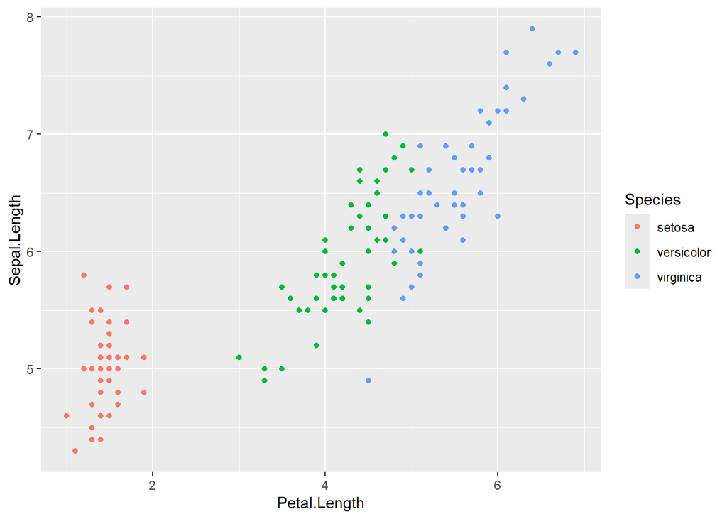

```r
ggplot(data = iris, #<--THE DATA SET
       mapping = aes(x = Petal.Length, #<--MAPPING OUR AESTHETICS. WE'RE SAYING "*THIS* VARIABLE IN THE DATA SET SHOULD USE *THAT* VISUAL CHANNEL IN THE GRAPH". HERE, WE'VE MAPPED PETAL LENGTH TO HORIZONTAL (X) POSITION AND SEPAL LENGTH TO VERTICAL (Y) POSITION.
           y = Sepal.Length)) +
  geom_point(mapping = aes(color = Species)) #<--WE ALSO MAP SPECIES TO THE VISUAL CHANNEL OF COLOR, BUT ONLY IN THIS ONE LAYER OF THE PLOT (THE ONLY LAYER, AT THIS POINT).
```

This graph is simple and reasonably effective—it’s perfectly suitable for exploration and informal sharing!

…However, for presentation or publication, it falls short (at least, in my professional opinion! YMMV) in several important respects. Some of these include:

- **Text size**: The default text size for axis and legend text is too small for easy reading, especially for those with a notable amount of visual impairment (something that tends to rapidly advance with age, and the world’s population is aging). A common rule of thumb is to size text such that it feels *almost* **too** large to help ensure it’s large *enough* for someone with visual impairment. Said differently, one should err on the side of sizing important elements as big as they can get away with before doing so leads to other design problems.
- **Point size**: The points are also quite small, which could hinder readability. The same mindset applies here—data elements should be as large and conspicuous as can be afforded.
- **Color palette**: `ggplot2`’s default “rainbow” color palette lacks variance in **lightness** (how “bright” or “dark” the color is, aka how close to white/black it is). For a person with colorblindness (especially red-green colorblindness), the red and green shades are very difficult to distinguish. For those with no color vision at all, or for those using black-and-white viewing technologies (both of which are surprisingly common situations), all three colors used would be virtually indistinguishable.
- **Foreground/background contrast**: While **contrast** (the ease with which nearby elements can be readily distinguished from one another) between the points and the background here is *ok*, it could be improved by using darker points and/or a lighter plot background. As noted above, it’d also help to have different color shades used for the points such that they contrasted better with each other. High contrast is critical for accessible and quickly interpretable graphs.
- **Whitespace and layout**: Default `ggplot`s can suffer from cramped layouts in some respects. When disparate elements (e.g., data points and axis labels) are very close together, it can be slower and more cognitively taxing to visually and mentally separate them. In particular, spacing in ggplots can often be tight between:
  - Axis **titles** and their corresponding axis **labels.**
  - Items within the **legend(s).**
  - Axis labels on densely labeled axes (not as much so here, but it’s a common issue)

  Adding more **void space** (space not housing an element) between components helps readers visually parse and process them easier and faster, especially those with significant cognitive or visual impairment.
- **Axis readability**: In `ggplot2`, axis and legend titles and labels default to the column names/values found in the data set unless the user sets custom text for them. These default title/label strings are often “computer-y” (e.g., they lack spaces, have unusual capitalization, and contain punctuation instead of spaces, etc.) rather than human-readable. Axis titles and labels should have standard spelling, spacing, and punctuation, and they should be human-interpretable. They should also contain units, if applicable, and avoid the use of obtuse abbreviations when possible.
- **Gridlines**: The research on the merits of gridlines is, admittedly, mixed! They:
  - *Can* lack contrast with the background and with nearby data elements.
  - Increase **cognitive load** (the amount of mental effort needed to integrate the available information to form a conclusion) by adding visual information to the plotting area that must be parsed and either integrated or (more likely) dismissed. When they’re not needed (and, arguably, they very often aren’t!), they constitute visual clutter that slows down interpretation.
  - Are unhelpful when rendered for a categorical variable (the default behavior in `ggplot2`, though not applicable to this graph).

  On the flip side, gridlines are familiar to novice readers and can thus serve as a “foothold” for them to begin to understand a graph. They can also help readers estimate exact values when this is required (though, arguably, it very often isn’t!).

  By and large, though, most data visualization experts agree that graphs are **not** the most efficient device for conveying exact values. Text, tables, and raw-data-file sharing are all superior! The adage to remember is that graphs ought to *primarily* be about “vibes!”  
  So, gridlines are *often* unnecessary. However, when a designer does deem them to be valuable, research has shown they can and should be as faint and as infrequent as possible to minimize their costs relative to their benefits. This advice does not generally correspond well to `ggplot2`’s default behaviors.
- **Incomplete axis labeling**: Axes should generally include tick marks and labels at both ends of the data range. This aligns with reader expectations (especially those of novice readers) and aids in efficient comprehension of the data. Axes are essentially “number lines,” and so should be completely graduated by labels, just like number lines are. On this graph, though, both axes are missing one or more labels near the upper/lower limits of the data, which makes these axes feel visually “unfinished,” as though the software just “forgot” to label all the way up to the ends!
- **Overplotting**: When data elements partially or wholly overlap with one another (a *very* common problem in point-based graphs like scatterplots), it becomes hard to judge how many elements are present in a location. This limits the reader’s ability to gauge data **density**. This is a hard data-viz problem to fix, but `ggplot2`’s default settings do not attempt to address it at all; it simply stacks any number of points on top of one another invisibly.
- **Vertically oriented y-axis title**: Research has consistently shown that text rotated away from horizontal (0 degrees) is harder to read for virtually every human on Earth—but especially for dyslexics, non-native readers of the language, users with motor or visual impairment, and those with certain technological limitations, among others. Despite this, the y-axis title is almost always rotated 90 degrees from horizontal in scientific graphs (not just in ggplots). This also means that it’s printed in a relatively unprominent location (in the left margin), so it’s not one of the first elements a reader is likely to encounter. Since many graphs are “about” the y-axis variable, the y axis title deserves a more prominent location so readers encounter it sooner.
- **Tick marks**: The **tick marks** on the axes are small and easily lost visually, though they can provide many of the same benefits of gridlines with much less cognitive load (they are the “gradations” on the “number lines”). These could be more prominent
- **Missing axis lines**: To better visually represent “number lines,” and to also better demarcate the boundary between the plotting area and the axes areas, most graphs feature axis lines. However, `ggplot2`’s graphs tend to lack such lines by default.
- **Legend placement**: `ggplot2`’s default legend location (in the right-hand margin) is often space-inefficient, creating needlessly large voids above/below it. Plus, it tends to be encountered by readers relatively late when placed in this location. Data visualization best practices are to either integrate a legend’s information into the plotting area directly (e.g., through direct labeling of lines) or else to place the legend somewhere both more prominent and more compact.

This list isn’t exhaustive, but it illustrates how even a simple `ggplot` could require many adjustments to meet accessibility, clarity, and design standards. It has been my personal experience that going from a base ggplot to a publishable one often requires several hundreds of lines of code-based adjustments! Not everyone has the time, patience, or wherewithal to do that much fiddling for every graph they make: hence, `ggplotplus`. It bundles together many of those hundreds of lines of code so that we can all just *start* much closer to where most of `us` would want to *finish*!

## 6 theme_plus: An Opinionated Starting Point

With many of the design challenges outlined above in mind, `ggplotplus` introduces the `theme_plus()` function, its core tool. A corollary to `ggplot2`’s `theme()` function, `theme_plus()` is designed to work identically. More experienced `ggplot2` users will know `theme()` to be one of `ggplot2`’s workhorse functions; it exposes many hundreds of toggles for adjusting a graph’s appearance, and it’s one of the functions perhaps most responsible for `ggplot2`’s not inconsiderable learning curve.

The intention of `theme_plus()` is to rewrite many dozens of the “presets” inside of `ggplot2`’s default `theme()` so that you don’t have to! Just tack it on to any `ggplot` call, even with no inputs, to access its benefits:

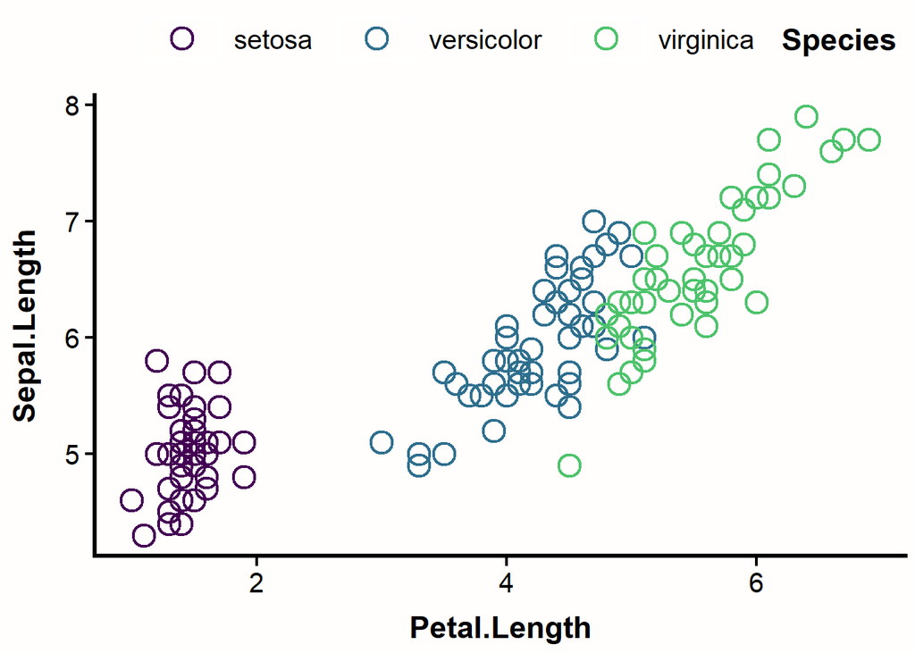

```r
#THE EXACT SAME GGPLOT COMMAND AS BEFORE...
ggplot(data = iris,
       mapping = aes(x = Petal.Length,
           y = Sepal.Length)) +
  geom_point(mapping = aes(color = Species)) +
  theme_plus() #<--...BUT WITH ggplotplus'S theme_plus FUNCTION TACKED ON.
```

Hopefully, you can already see how big a difference this one function can make to the design of a graph! Let’s discuss some of these design improvements in greater detail:

- **Larger text** throughout for better readability.
- **Increased spacing** between key elements (like legend keys within the legend and between axis titles and their corresponding labels).
- **Thicker and longer axis ticks** for greater visibility and easier distinguishing between them and data elements and between them and axis lines.
- **Remove gridlines** by default (see later section on `gridlines_plus()` for how to selectively reintroduce them).
- **White background** for highest contrast against most standard foreground elements (well, technically, it’s a very subtle, warm off-white, since true white can increase eyestrain with prolonged viewing).
- **Black axis lines** at the bottom and left for visual anchoring (but no top or right borders, which typically communicate no information and thus are extraneous).
- **Legend moved above the plot** as a horizontal stripe, which is more space-efficient and increases the likelihood it will be encountered early by readers.
- **All text rendered in black**, rather than the default dark gray for some elements, to maximize contrast with the light background.

Of course, everything is still customizable. If you don’t love a particular choice—say, the thickness of the axis lines or the legend’s location—you can adjust them, same as you normally would using `theme()`, except that you can pass the overrides straight into `theme_plus()` instead:

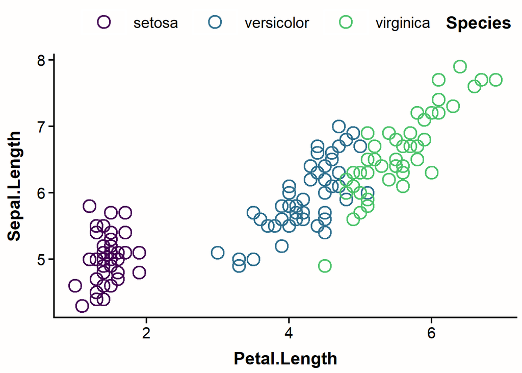

```r
#THE EXACT SAME GGPLOT COMMAND AS BEFORE...
ggplot(data = iris,
       mapping = aes(x = Petal.Length,
           y = Sepal.Length)) +
  geom_point(mapping = aes(color = Species)) +
  theme_plus(axis.line = element_line(linewidth = 0.75)) #<--WE CAN MAKE THE AXIS LINES A LITTLE THINNER IF WE WANT.
```

Here’s how you’d relocate the legend to its standard `ggplot2` position. The theme will automatically apply some enhanced default styling specific to this position instead:

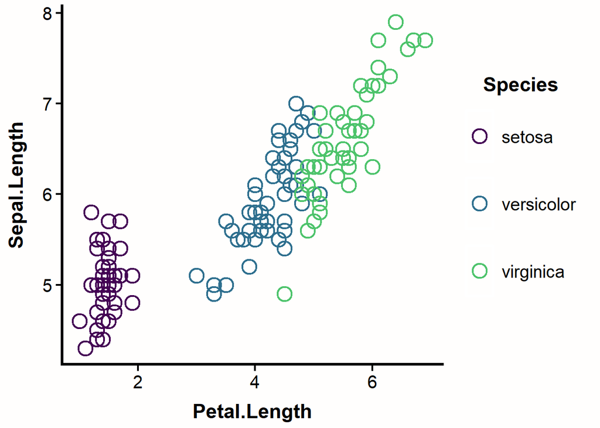

```r
#THE EXACT SAME GGPLOT COMMAND AS BEFORE...
ggplot(data = iris,
       mapping = aes(x = Petal.Length,
           y = Sepal.Length)) +
  geom_point(mapping = aes(color = Species)) +
  theme_plus(legend_pos = "right")
```

Like the rest of the `ggplotplus` toolkit, `theme_plus()` is meant to be a smart starting point, **not** a “final destination.” Its outputs won’t be ideal for every plot, person, or context (that’s not even remotely possible!), but it’s designed to save you time by making it so there are *fewer* adjustments you need to make to get your graphs to where they ultimately need to be: fully accessible for the entire audience you want!

### 6.1 Accessible Color Palettes

As previously noted, the default color palette used by `ggplot2` is not particularly accessible. Fortunately, the `viridis` package—bundled automatically with every installation of `ggplot2`—includes several palettes that were specifically designed for near-universal accessibility!

The way they achieve this is by featuring continuous variance in not just in **hue** (i.e., the base “color,” such as “red,” “green,” or “blue,” so what is conventionally thought about as “color”) but also in **lightness** (light vs. dark, aka “white” vs. “black”). This multidimensional variance makes the colors in these palettes more universally distinguishable from one another for a wide range of people in a wide range of circumstances.

Thanks to enhancements made to `ggplot2::theme()` as of the package’s 4.0.0 Version, released September 11, 2025, one can now set default color palettes within a theme (this used to require using R’s global options and was relatively inflexible). For example, one can do something like:

```r
###CODE TO BE ADDED TO A GGPLOT CALL TO SET A DEFAULT COLOR PALETTE
... +
ggplot2::theme(
    palette.colour.discrete = disc,
    palette.fill.discrete = disc,
    palette.colour.continuous = cont,
    palette.fill.continuous = cont
  )

### WHERE disc AND cont ARE SETS OF COLORS PULLED FROM A SPECIFIC PALETTE, SUCH AS VIRIDIS.
```

This allows `theme_plus()` to set more accessible default color palettes while still allowing a user to easily override these defaults with their own preferences, either by replacing one of the `palette.*.*` inputs above within `theme_plus()` or by adding a `scale_*_*()` call to their plot as they normally might in order to specify desired colors.

`theme_plus()` uses the titular `viridis` palette for discrete variables and the `cividis` palette for continuous variables. By default, `viridis` ranges from dark purple to light yellow, passing through blue, green, and teal. This relatively large number of hues makes it relatively easy to produce several discrete hues that are visually contrasting with each other as well as with whatever background color you use.  
However, it excludes, by default, the lightest yellow hues from the `viridis` palette because these tend to lack contrast with other light-colored elements as well as with backgrounds in ggplots, when tend to be white. As a result, the remaining palette includes just the purple/blue/teal/green region. However, you can easily adjust this using the function’s `begin_discrete` and `end_discrete` input parameters, which take values ranging between 0 and 1:

- `begin_discrete = 0.28` would disable the dark purple portion of the color range, such as when you have many other dark elements or a dark background.
- `end_discrete = 1` would enable the light yellow portion, such as when you don’t have other light elements or a light background.

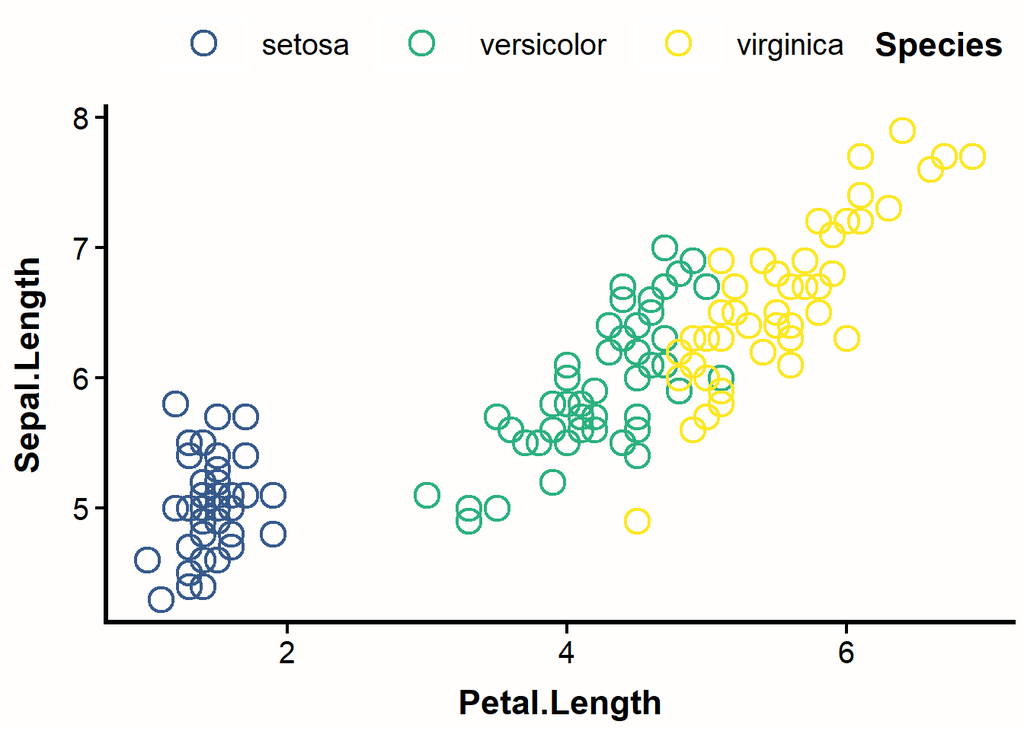

```r
#SAME GRAPH AS BEFORE EXCEPT...
ggplot(data = iris,
       mapping = aes(x = Petal.Length,
           y = Sepal.Length)) +
  geom_point(mapping = aes(color = Species)) +
  theme_plus(begin_discrete = 0.28,#<--DISALLOW DARK PURPLE REGION.
              end_discrete = 1) #<--ALLOW YELLOW REGION.
```

In this example, I’ve disabled the purple end of the palette and I’ve enabled the yellow region, which means I have some points that now lack contrast with the background. But no worries–that’s something I can fix!

### 6.2 Continuous color scales

To see the default color palette for a continuous variable, let’s temporarily map color to a numeric variable instead:

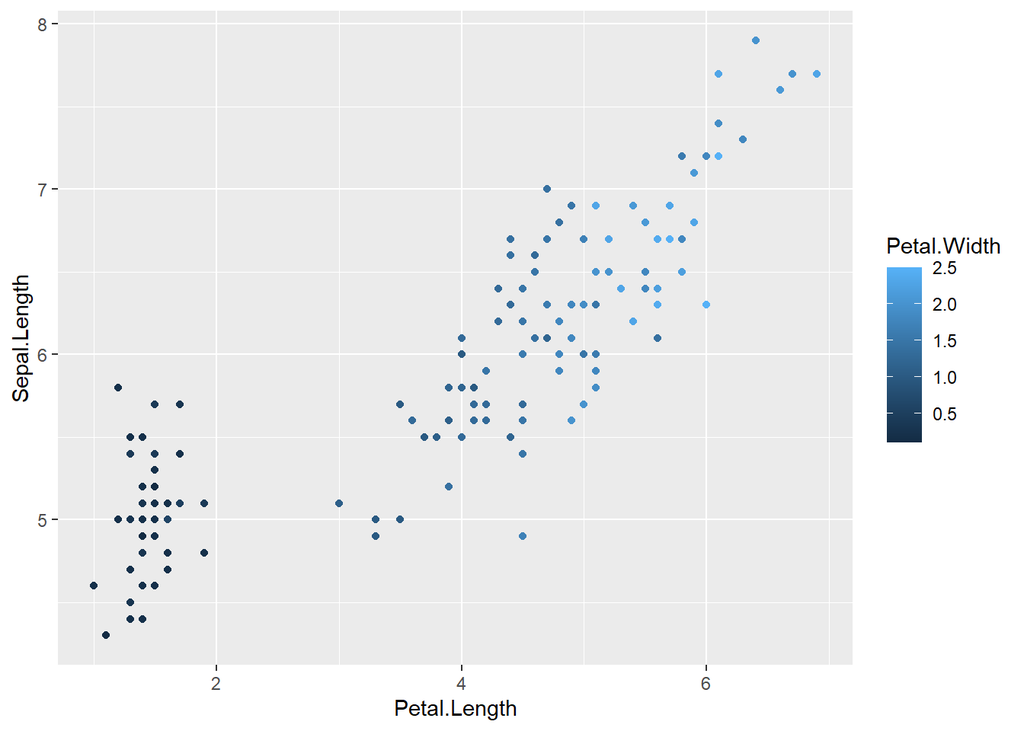

```r
#A BASE GGPLOT2 GRAPH WITHOUT theme_plus() ON FOR REFERENCE
ggplot(iris,
       mapping = aes(x = Petal.Length,
           y = Sepal.Length)) +
  geom_point(mapping = aes(color = Petal.Width)) #<--MAP COLOR TO A CONTINUOUS VARIABLE.
```

The default `ggplot2` palette for continuous variables is “blues,” which is a reasonable palette in that it does vary in lightness, making it more broadly accessible. However, it doesn’t vary in hue, which can make nearby values harder to distinguish. As such, `theme_plus()` changes the palette to `cividis`, which has three distinct hues: blue, gray, and yellow:

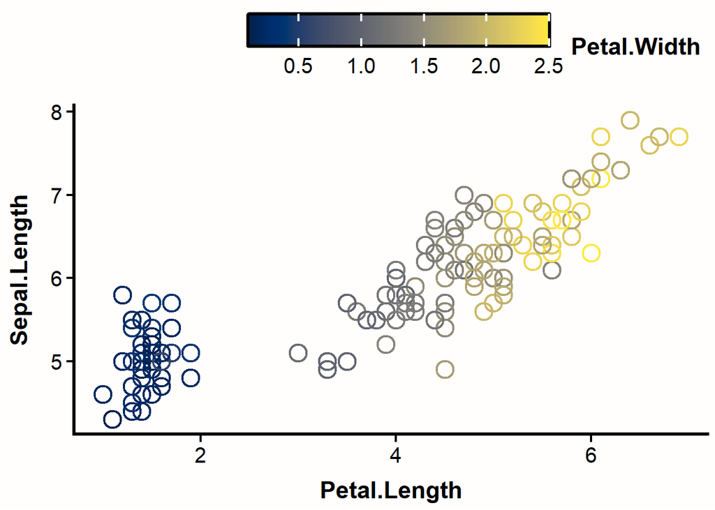

```r
ggplot(iris,
       mapping = aes(x = Petal.Length,
           y = Sepal.Length)) +
  geom_point(mapping = aes(color = Petal.Width)) +
  theme_plus()
```

Because humans like to “chunk” data into discrete groups according to hue, even in circumstances where the underlying phenomenon is continuous and nothing “special” is happening at the points of hue transition, this palette’s low number of hues results in less “false binning” of the data than tends to happen when using palettes with more distinct hues (such as `viridis`). After all, blue, gray, and yellow points here *are* quite different, so the hue differences many will perceive map accurately to differences in the underlying data, and even relatively similar values are more easily distinguished from one another.

### 6.3 Geometries with Opinionated Defaults

Another major feature of `ggplot2`’s 4.0.0 update was to allow users to set many geometry-layer-specific design settings within `theme()`. These used to have to be set in each individual `geom_*()` layer separately. For example, a user can now add a `theme()` call of the following form to their graphs:

```r
###EXAMPLE ADJUSTMENT OF GEOMETRY-LAYER-SPECIFIC DESIGN SETTINGS FROM WITHIN THEME.
... +
ggplot2::theme(geom = ggplot2::element_geom(pointsize = 5)) #SET THE DEFAULT POINT SIZE FOR ALL GEOMS USING POINTS TO 5.
```

This functionality allows `theme_plus()` to replace many of the default settings of many commonly used geometry layers automatically.

For example, in the above graph, one can see that `theme_plus()` has made:

- The points are **larger** and thus easier to parse.
- The **shape** of these points hollow circles (by changing the default shape from R’s shape 16 to shape **21)**.

The latter change is important because shape 16 only supports the `color` aesthetic, whereas shape 21 supports **both** `color` (for the stroke/outline) and `fill` (for the interior). This affords more flexibility in design choices.

Specifically, by default, `theme_plus()` set the interior color for points to `"transparent"`, resulting in **hollow circles**. This allows **partial overlaps** between points to be more readily distinguishable—though, of course, total overlap would still not discernible.

### 6.4 Improving Contrast with the Fill Aesthetic

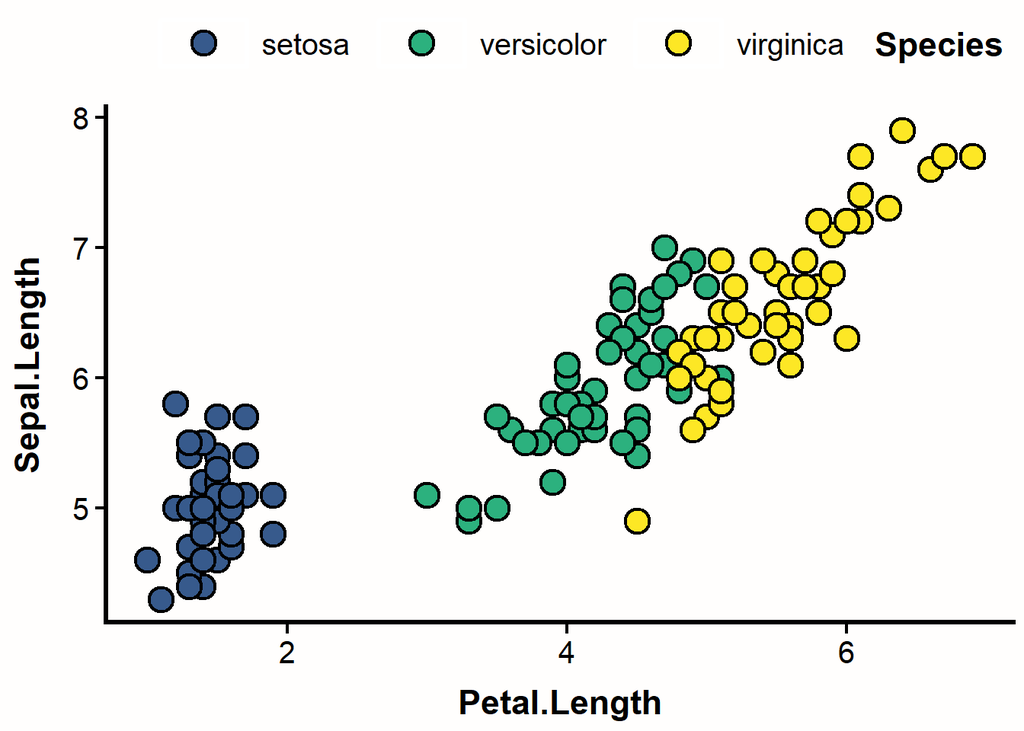

```r
#SAME GRAPH AS BEFORE EXCEPT...
ggplot(data = iris,
       mapping = aes(x = Petal.Length,
           y = Sepal.Length)) +
  geom_point(mapping = aes(fill = Species)) + #<--CHANGING TO MAPPING SPECIES TO FILL.
  theme_plus(begin_discrete = 0.28,
              end_discrete = 1)
```

Notice how this change fixes our earlier issue of our yellow points lacking contrast against the light background. This happens because the fill colors are now surrounded by **black outlines**, so our eyes will compare the fill color to the black (the most proximal other color) rather than to the background. A neat trick, based on how the science of vision works!

Even though dark purple wouldn’t have sufficient contrast against a black outline, that’s not actually a problem because the point strokes aren’t encoding information. As a result, if I wanted to make the colors being used even more distinct, I could restore the full range of the *viridis* palette:

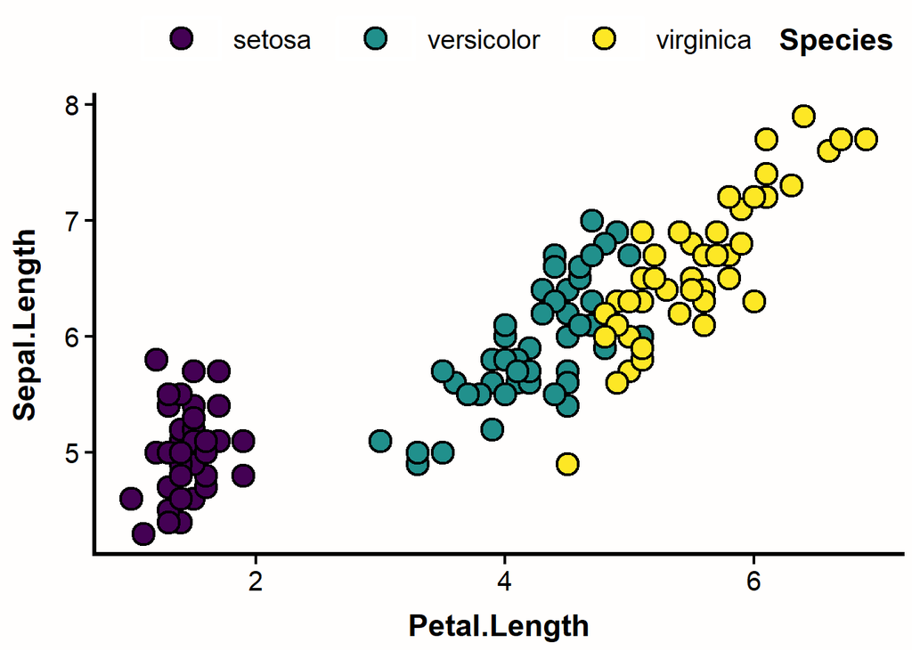

```r
#SAME GRAPH AS BEFORE EXCEPT...
ggplot(data = iris,
       mapping = aes(x = Petal.Length,
           y = Sepal.Length)) +
  geom_point(mapping = aes(fill = Species)) +
  theme_plus(begin_discrete = 0, #<--EXCEPT BACK TO 0 TO INCLUDE PURPLE
              end_discrete = 1)
```

Purple points still look purple, whether I can distinguish their black outlines from their fill colors or not. Meanwhile, all points are easily distinguished from the background, so I can utilize the entire color space available in the palette!

### 6.5 Resolving overplotting

Ok! Back to the issue of extreme overplotting here. There are two broadly effective options for addressing overplotting in graphs like this one. The first, as you’ve already seen, is to pick a shape with separate `color` and `fill` aesthetics, then map `color` to the stroke and set the `fill` to `"transparent"` so that partial overlap between the points is evident.

However, another, more aggressive option is to instead map stroke to a `color` that contrasts against the background well (such as black for a white background), map `fill` color to your variable of interest, and then make the points *semi-transparent* so that points stacked on top of one another “blend” into one another chromatically. This is easier to see than to read:

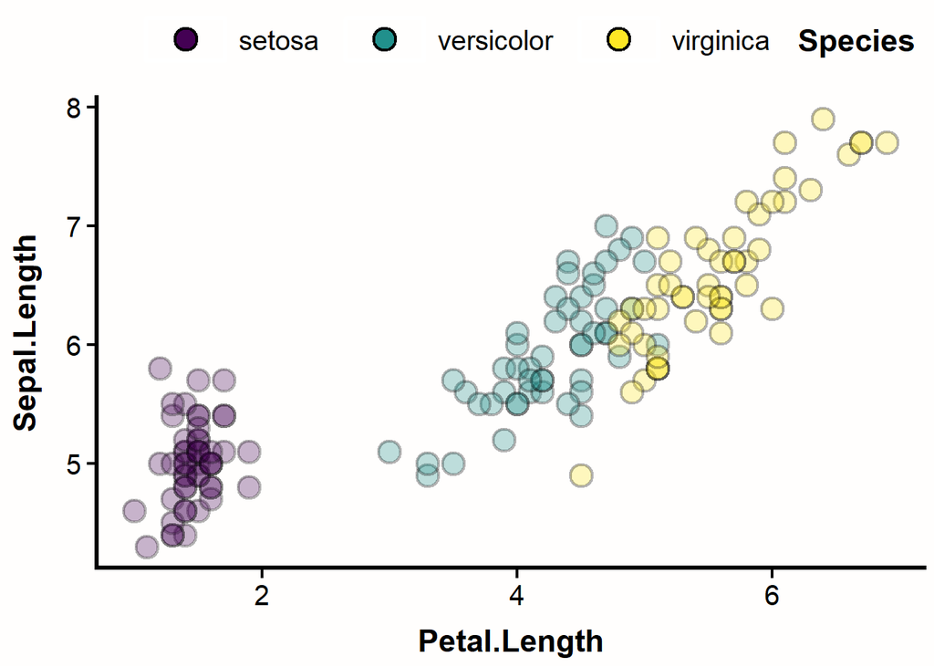

```r
#SAME GRAPH AS BEFORE EXCEPT...
ggplot(data = iris,
       mapping = aes(x = Petal.Length,
           y = Sepal.Length)) +
  geom_point(mapping = aes(fill = Species),
             alpha = 0.3) + #<--ADD IN STRONG SEMI-TRANSPARENCY VIA ALPHA.
  theme_plus(begin_discrete = 0,
              end_discrete = 1)
```

At `alpha = 0.3`, individual points maintain sufficient contrast with the background, but points in dense regions of the data space layer on top of each other, resulting in darker (or even blended) colors. This makes it possible for a reader to understand not just the position and group identity of points but their density as well.

Note: This approach also dims the **black point strokes**, so contrast could still be a concern for low-vision readers with the yellow fill colors. Additionally, variance in lightness will be reduced by using transparency, which can make the graph harder to view in grayscale. Color (and overplotting) in graphs is challenging to navigate! When overplotting is a serious concern, consider whether a scatterplot is the best way to represent your data, and whether you need to plot *all* your data to achieve your goals.

### 6.6 Easier-To-Read Legend Keys

Did you notice: In the previous graph, even though I adjusted the transparency of the points using `alpha`, the legend key symbols retained full opacity? That’s another `ggplotplus` default design opinion: legend keys should always be readable!

When points are made smaller (`size` is adjusted downward) and/or points are made semi-transparent (`alpha` is adjusted downward), `ggplot2`’s default behavior is to apply these same changes to the legend key symbols as well. However, this might make those symbols harder to read. For example:

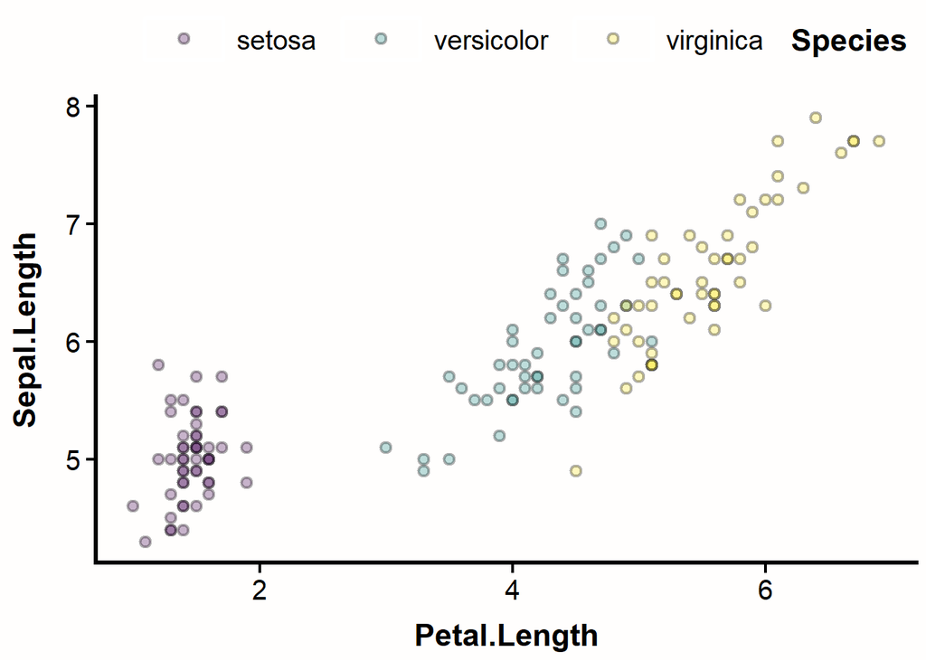

```r
ggplot(data = iris,
       mapping = aes(x = Petal.Length,
           y = Sepal.Length)) +
  geom_point(mapping = aes(fill = Species),
             alpha = 0.3,
             size = 2) + #<--MAKE POINTS MUCH SMALLER
  theme_plus(begin_discrete = 0,
              end_discrete = 1,
             override_legend_alphasize = FALSE #<-DISABLE LEGEND KEY OPINIONS
              )
```

In this graph, I’ve reduced the size and opacity of the points, and now it’s pretty difficult to differentiate the legend keys.

Now, there might be reasons one would want points *within the plotting area* to be smaller and/or more transparent! But unless variation in point size/transparency conveys information about differences (e.g., these aesthetics *aren’t* constants, i.e., you’ve *mapped* them to variable data), it’s often undesirable from a readability standpoint to apply these same traits to the legend key symbols too.

So, `ggplotplus` will coerce legend key symbols back to full opacity and a reasonable size (`5`) unless you:

- Set `override_legend_alphasize` to `FALSE`, as I did above (this can also be done via `gridlines_plus()` and `yaxis_title_plus()` as well!).
- You set `guide = 'none'` inside a `scale_*` function or `guides()`.
- You specify your own legend overrides for `size` and/or `alpha` via `guide_legend(override.aes = list(...))`.

If you map just one of the two aesthetics, the overrides will automatically apply to only the other. For example:

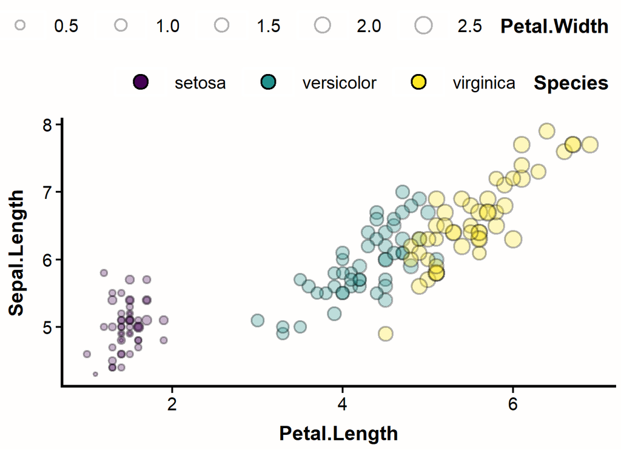

```r
###PLOTTING WINDOW NOW RESCALED TO A WIDTH OF 7 INCHES X 5.26 INCHES

ggplot(data = iris,
       mapping = aes(x = Petal.Length,
           y = Sepal.Length)) +
  geom_point(mapping = aes(fill = Species,
                           size = Petal.Width), #<-MAP SIZE TO A COLUMN IN OUR DATA SET.
             alpha = 0.3) +
  theme_plus(begin_discrete = 0,
              end_discrete = 1)
```

Here, I set size to vary as a function of a variable, so variation in point size now conveys meaning. Our point size legend (top) respects that. However, our point alpha adjustment is ignored in both legends, and the fill legend (bottom) continues to use a large, constant size.

### 6.7 Aside: ggplot2 defaults to mapping size to area, not radius

As a quick aside, I’ll note that `ggplot2`, by default, already maps point `size` to area, not radius (see [this part of the `ggplot2` book](https://ggplot2-book.org/scales-other#sec-scale-size)). This is important because, as radius increases, area increases *faster*, and humans perceive differences in point area more strongly than we perceive differences in point radius. So, it’s worth applauding that this default behavior is already preventing a potential perceptional distortion.

### 6.8 Detour: Mapping Visual Channels in `ggplot2` (a Review)

In `ggplot2`, you can partially control the visual appearance of your graph using **aesthetics**, which connect **visual channels** (like position, color, size, or fill) to variables in your data set or set them to constant values.

There are three (partially overlapping) ways to assign aesthetics:

1. **Global mapping**: Inside `aes()` in the `ggplot()` call. These mappings apply to *all* layers (or “geoms”).
2. **Local mapping**: Inside `aes()` within a specific `geom_*()` call. These *only* apply to the layer they are included within.
3. **Constants**: Set inside or outside `aes()` within a geom or inside of `aes()` within `ggplot()`. This will fix the aesthetic to a single value, e.g., setting all colors to “red,” that will override any conflicting mapping.

This system gives you flexibility, but it can be confusing—especially for new users. Let’s clarify with an example that uses two geoms: a boxplot overlaid with **jittered** points (jittering randomly varies a point’s location data):

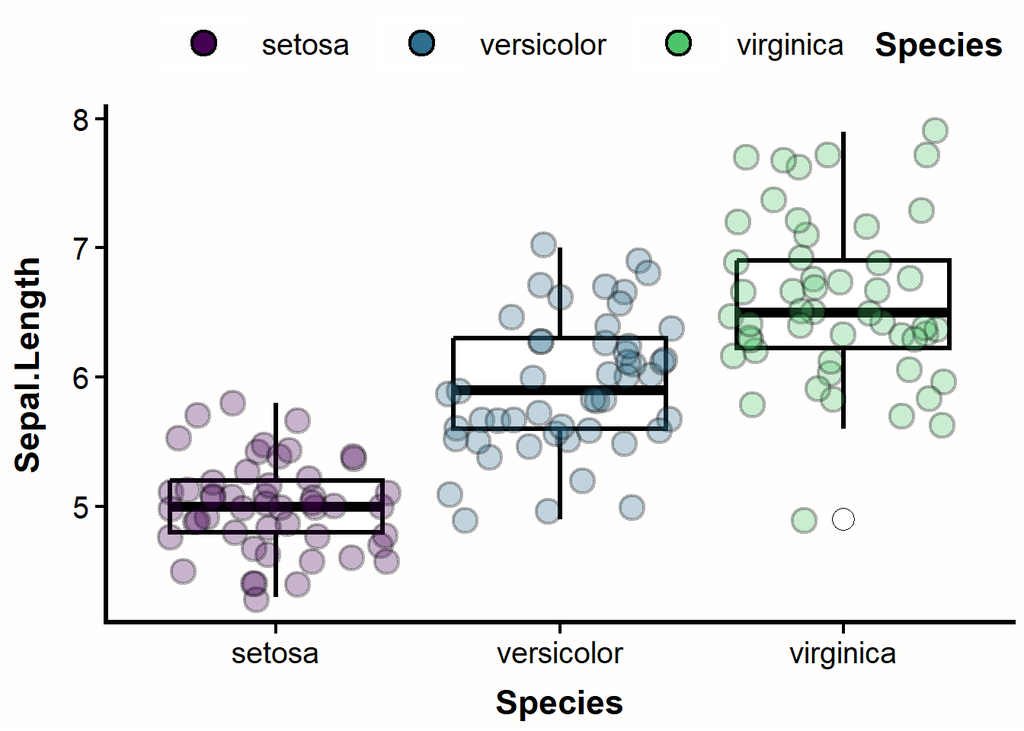

```r
#NEW PLOT
ggplot(iris,
       mapping = aes(x = Species, #<--MAKE THIS SPECIES, A DISCRETE VARIABLE
           y = Sepal.Length)) +
  geom_boxplot() + #<--A NEW GEOM = BOXPLOT
  geom_jitter(#<--SAME AS GEOM_POINT EXCEPT JITTERED.
            mapping = aes(fill = Species),
            alpha = 0.3) +
  theme_plus()
```

Here’s what’s happening:

- **Global mappings** of `x = Species` and `y = Sepal.Length` apply to *both* the boxplot and the jittered points layers.
- The **fill aesthetic** is mapped to `Species`, but **only locally** within the jittered points layer, so the boxplots are unaffected and don’t get species-specific fill colors.
- The **alpha aesthetic** is set to a constant (0.3), again **only locally** for the jittered points. This means all points get this value, but the boxplots are unaffected.

If you map the *same aesthetic* in multiple places (e.g., globally and locally), the **local mapping always wins**—it overrides any global specification for that layer. Also, if you try to map an aesthetic to both a variable *and* a constant, the constant (usually) wins.

#### 6.8.1 …So what?

I bring all this up just to say that all of the same rules apply when using `ggplotplus`. You can:

- Map aesthetics globally or locally.
- Map aesthetics to variables in your data set or set them to constants.
- Combine the approaches as needed–conflicts will resolve as they normally do in `ggplot2`.

Here’s a similar plot with a few tweaks to illustrate this further:

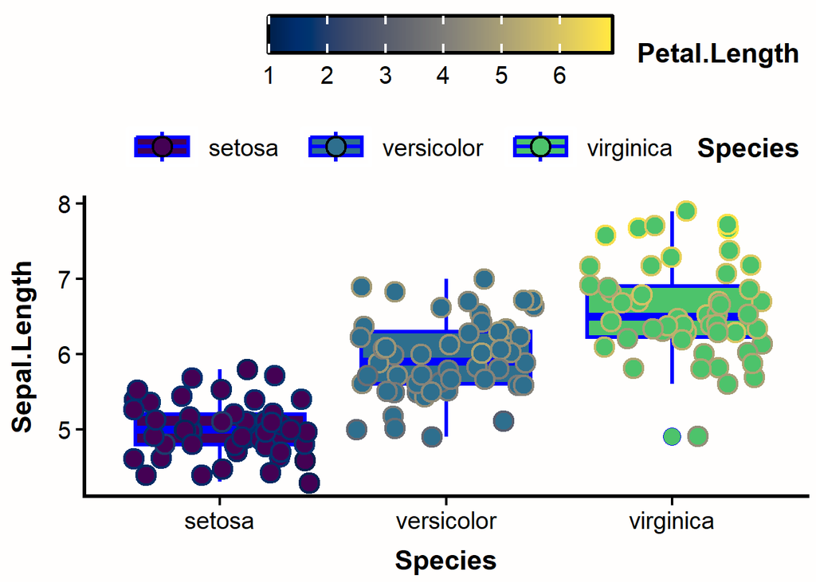

```r
ggplot(iris,
       mapping = aes(x = Species,
           y = Sepal.Length,
           fill = Species, #<-- WE CAN SWITCH TO MAPPING FILL GLOBALLY SO IT SHOULD APPLY TO BOTH GEOMS.
           color = Petal.Length)) + #<--WE ALSO MAP COLOR
  geom_boxplot(color = "blue") + #<--WE LOCALLY OVERRIDE COLOR, SO IT'LL BE BLUE FOR ALL BOXES INSTEAD OF LINKED TO PETAL LENGTH
  geom_jitter() + #<--SIMPLIFY HERE.
  theme_plus()
```

In this version:

- **Fill** is now applied to *both* geoms, since it’s being mapped globally inside of `ggplot()`.
- **Color** is also mapped globally but overridden locally in the boxplot layer (so boxplot outlines are blue, regardless of `Petal.Length`).

### 6.9 Geom Availability

Most common `ggplot2` geoms have defaults adjusted by `theme_plus()`, though not all. To see a list of those receiving specific adjustments, run this command:

```r
sort(names(geom_plus_defaults))
```

```
 [1] "abline"     "area"       "bar"        "boxplot"    "col"
 [6] "count"      "crossbar"   "curve"      "density"    "dotplot"
[11] "errorbar"   "freqpoly"   "histogram"  "hline"      "jitter"
[16] "line"       "linerange"  "point"      "point_plus" "pointrange"
[21] "ribbon"     "segment"    "smooth"     "tile"       "violin"
[26] "vline"
```

### 6.10 Improving Axes Breaks and Labels

Returning to our earlier scatterplot:

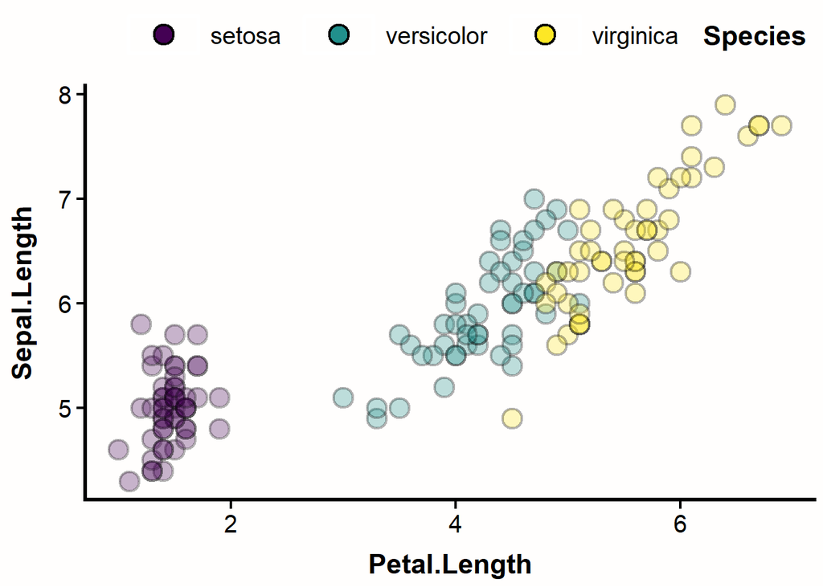

```r
ggplot(iris,
       mapping = aes(x = Petal.Length,
           y = Sepal.Length)) +
  geom_point(mapping = aes(fill = Species),
            alpha = 0.3) +
  theme_plus(begin_discrete = 0,
              end_discrete = 1)
```

There’s still room for improvement in its design, especially with respect to the *axis titles and labels*. A key first step in redesigning these would be to make the axis titles more human-readable, intuitive, and complete, including by specifying units. You can do this using the `scale_*_*()` family of functions in `ggplot2`:

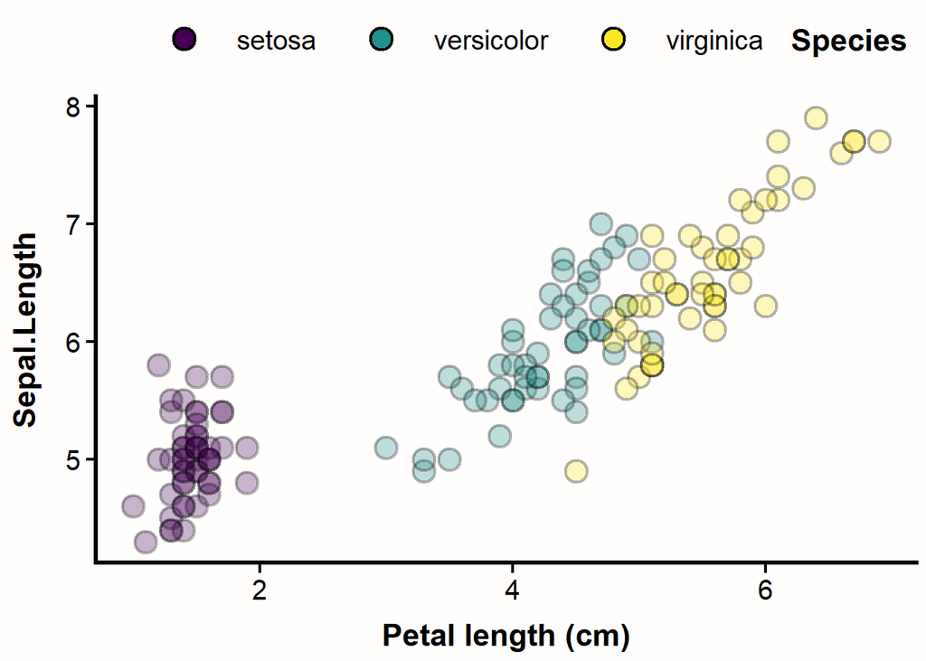

```r
ggplot(iris,
       mapping = aes(x = Petal.Length,
           y = Sepal.Length)) +
  geom_point(mapping = aes(fill = Species),
            alpha = 0.3) +
  theme_plus(begin_discrete = 0,
              end_discrete = 1) +
  scale_x_continuous(name = "Petal length (cm)") #<--STANDARD WAY IN GGPLOT2 TO CHANGE THE X AXIS TITLE FOR A NUMERIC VARIABLE.
```

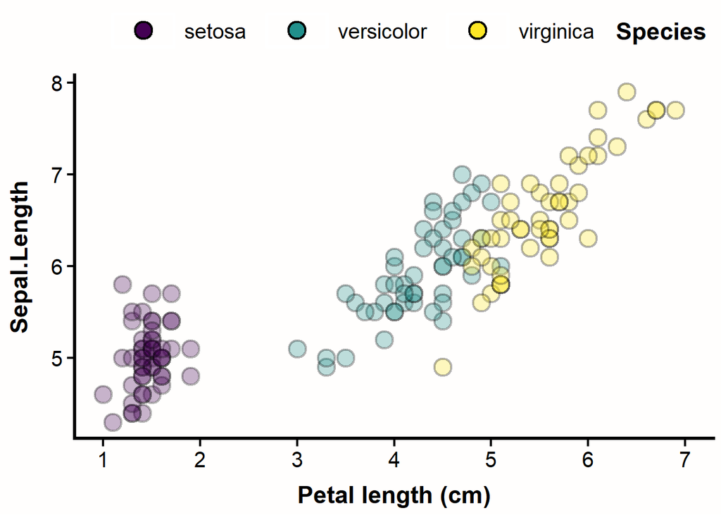

```r
ggplot(iris,
       mapping = aes(x = Petal.Length,
           y = Sepal.Length)) +
  geom_point(mapping = aes(fill = Species),
            alpha = 0.3) +
  theme_plus(begin_discrete = 0,
              end_discrete = 1) +
  scale_continuous_plus(scale = "x",#<--SWITCH TO THE ggplotplus VARIANT, AND SPECIFY THE SCALE.
    name = "Petal length (cm)")
```

The axis is now expanded to start with a break at 1 and to end with a break at 7, with breaks in between still chosen to be regular and “pretty,” just as in `ggplot2`.

As with the base `scale_*_*()` functions, you can pass arguments like `name`, `expand`, or `labels` to `scale_continuous_plus()`. However, you *cannot* manually set `breaks` or `limits`, since those are determined internally by the function.

If the resulting labels feel a little too frequent, `scale_continuous_plus()` contain a trick: You can set `thin.labels` to `TRUE` to convert every other label to an empty string (`""`) while retaining the tick marks:

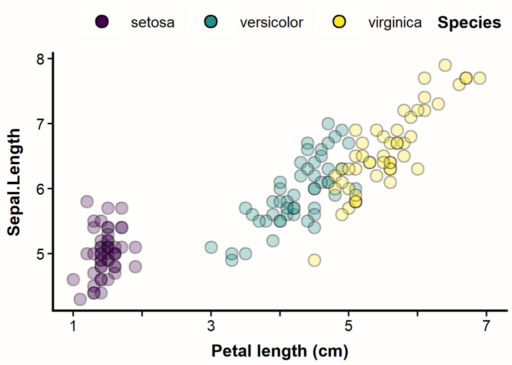

```r
ggplot(iris,
       mapping = aes(x = Petal.Length,
           y = Sepal.Length)) +
  geom_point(mapping = aes(fill = Species),
            alpha = 0.3) +
  theme_plus(begin_discrete = 0,
              end_discrete = 1) +
  scale_continuous_plus(scale = "x",
    name = "Petal length (cm)",
    thin.labels = TRUE) #<--WILL CONVERT EVERY OTHER LABEL TO AN EMPTY STRING.
```

This reduces cognitive load and increases void space while preserving the visual scaffolding the ticks provide. Optional, but a nice touch!

Applying this same logic to the y-axis is as easy as adding another `scale_continuous_plus()` call:

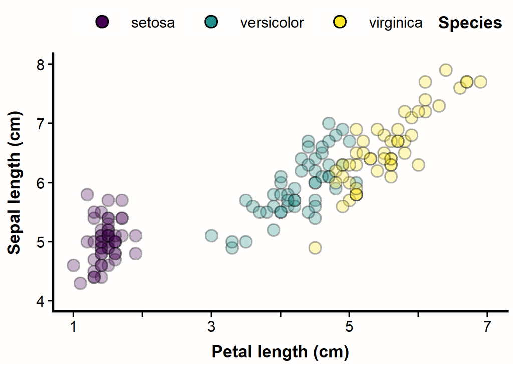

```r
ggplot(iris,
       mapping = aes(x = Petal.Length,
           y = Sepal.Length)) +
  geom_point(mapping = aes(fill = Species),
            alpha = 0.3) +
  theme_plus(begin_discrete = 0,
              end_discrete = 1) +
  scale_continuous_plus(scale = "x",
    name = "Petal length (cm)",
    thin.labels = TRUE) +
  scale_continuous_plus(scale = "y", #<--ANOTHER FOR Y.
    name = "Sepal length (cm)")
```

Here, the y-axis limits now extend down enough to add a break at 4, making the axis appear more complete and aiding interpretation.

`scale` can also be set to `fill` and `color` for when these are mapped to continuous variables. At the same time, there are a few considerations `theme_plus()` makes that apply only to color bars, which are the legend components you see when you map `color` or `fill` to a continuous variable. Let’s map a continuous variable to `fill` to get such a legend:

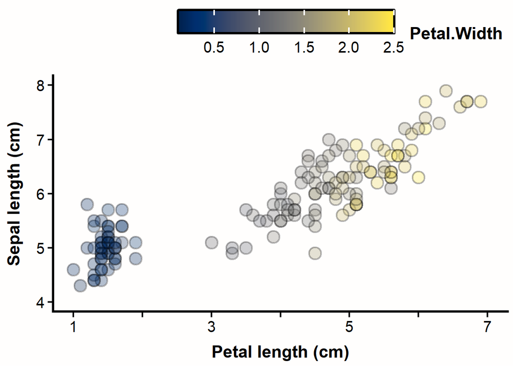

```r
ggplot(iris,
       mapping = aes(x = Petal.Length,
           y = Sepal.Length)) +
  geom_point(mapping = aes(fill = Petal.Width), #<--SWAP TO A CONTINUOUS VARIABLE.
            alpha = 0.3) +
  theme_plus() + #<--NO LONGER NEEDED--WE'LL USE FULL CIVIDIS SCALE.
  scale_continuous_plus(scale = "x",
    name = "Petal length (cm)",
    thin.labels = TRUE) +
  scale_continuous_plus(scale = "y",
    name = "Sepal length (cm)")
```

The `theme_plus()`-driven changes here include longer and fatter tick marks of pure white for maximum contrast against the colors within (at least, *usually*–there’s no perfect hue to use for this purpose!), a black border to prevent any contrast issues with the background, and larger dimensions for easier reading and enhanced visibility.

Note that color bars can have the same issue as axes, where the ends don’t always get labels. One can just add a third call to `scale_continuous_plus()` to help with that:

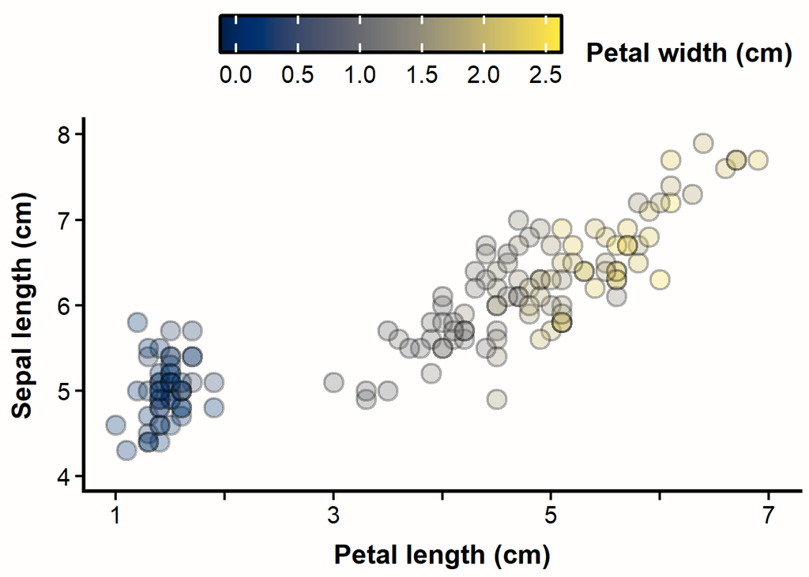

```r
ggplot(iris,
       mapping = aes(x = Petal.Length,
           y = Sepal.Length)) +
  geom_point(mapping = aes(fill = Petal.Width),
            alpha = 0.3) +
  theme_plus() +
  scale_continuous_plus(scale = "x",
    name = "Petal length (cm)",
    thin.labels = TRUE) +
  scale_continuous_plus(scale = "y",
    name = "Sepal length (cm)") +
  scale_continuous_plus(scale = "fill",
    name = "Petal width (cm)") #<--ADD A THIRD FOR FILL
```

The left-hand side of the colorbar’s scale has expanded to include 0 so that it’s clearer to the reader exactly which color would correspond to a value of `0`.

`scale_continuous_plus()` has another handy feature that is often of value for legend titles, specifically: set `split_name` to `TRUE` to break the legend onto many lines by spaces in the original entry:

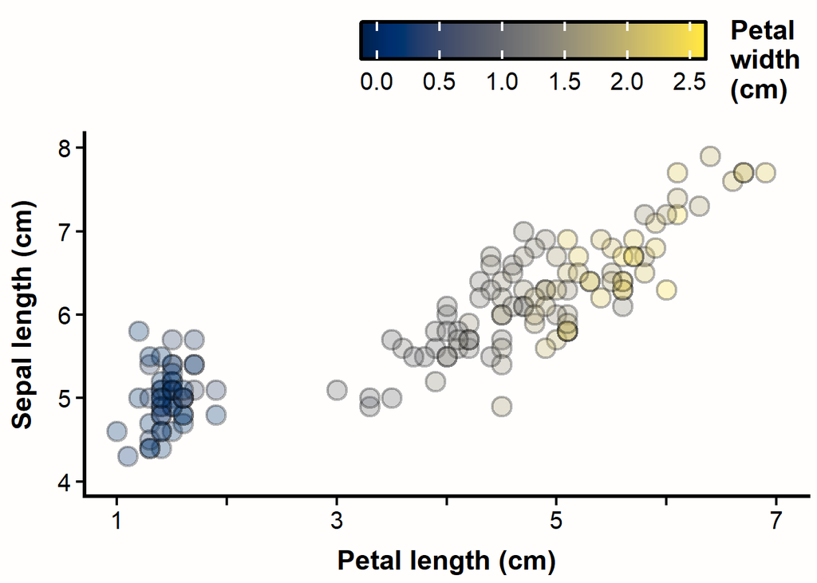

```r
ggplot(iris,
       mapping = aes(x = Petal.Length,
           y = Sepal.Length)) +
  geom_point(mapping = aes(fill = Petal.Width),
            alpha = 0.3) +
  theme_plus() +
  scale_continuous_plus(scale = "x",
    name = "Petal length (cm)",
    thin.labels = TRUE) +
  scale_continuous_plus(scale = "y",
    name = "Sepal length (cm)") +
  scale_continuous_plus(scale = "fill",
    name = "Petal width (cm)",
    split_name = TRUE  #DIVIDE ONTO NEW LINES BY SPACES
    )
```

You can still provide a vector of custom axis labels to `scale_continuous_plus`, like you can with its `ggplot2` counterparts, but it requires a little trial and error. Because `scale_continuous_plus` must “experiment” to find the right limits and breaks for your scale, it may ultimately create breaks outside the limits shown and which are thus invisible. As such, you may need to provide more labels (including 1 or 2 blank labels on either side) than it appears you’d need. However, if you provide fewer labels than are strictly required, the function makes an educated guess about how to pad them to display properly:

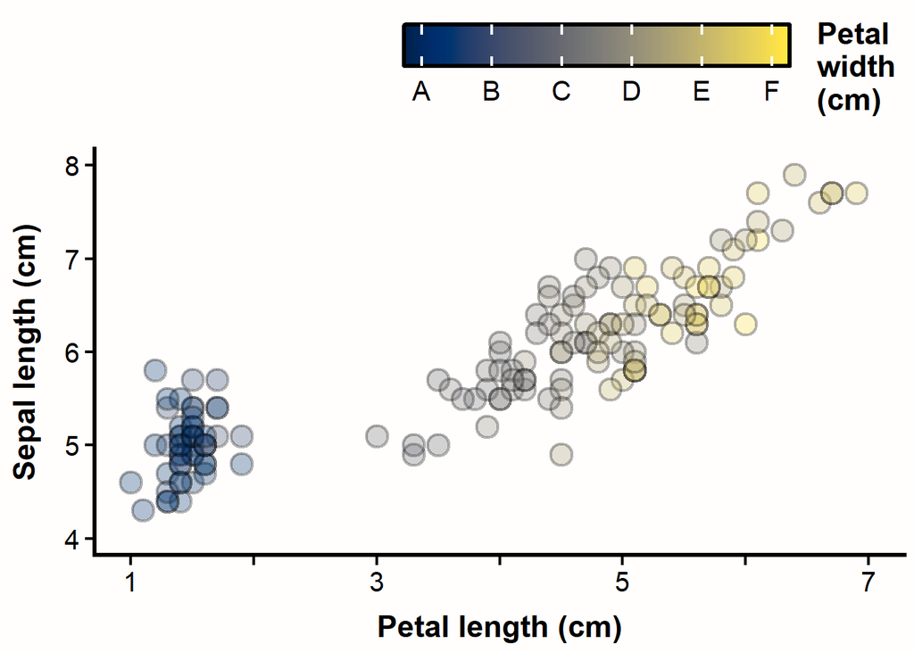

```r
ggplot(iris,
       mapping = aes(x = Petal.Length,
           y = Sepal.Length)) +
  geom_point(mapping = aes(fill = Petal.Width),
            alpha = 0.3) +
  theme_plus() +
  scale_continuous_plus(scale = "x",
    name = "Petal length (cm)",
    thin.labels = TRUE) +
  scale_continuous_plus(scale = "y",
    name = "Sepal length (cm)") +
  scale_continuous_plus(scale = "fill",
    name = "Petal width (cm)",
    split_name = TRUE,
    labels = LETTERS[1:6] #ONLY 6 BREAKS ARE SHOWING, BUT ACTUALLY, THERE ARE 8, BEHIND THE SCENES! NO MATTER--THE FUNCTION PADS YOUR VECTOR WITH BLANK LABELS ON EITHER SIDE AS NEEDED.
    )
```

To know how many labels you need to provide, you may need to render your plot first to see what breaks the function has chosen, then provide a vector of labels to match.

## 7 Y Axis Title Orientation and Location

Our graph is nearly “perfect” (at least, in our estimation!)—but one significant design issue remains: the **y-axis title** is still vertically oriented and tucked away in the plot’s left-hand margin. Let’s change that.

In base `ggplot2`, you *can* reorient the title to be horizontal, at least, using a few hacky adjustments involving line breaks and theme tweaks:

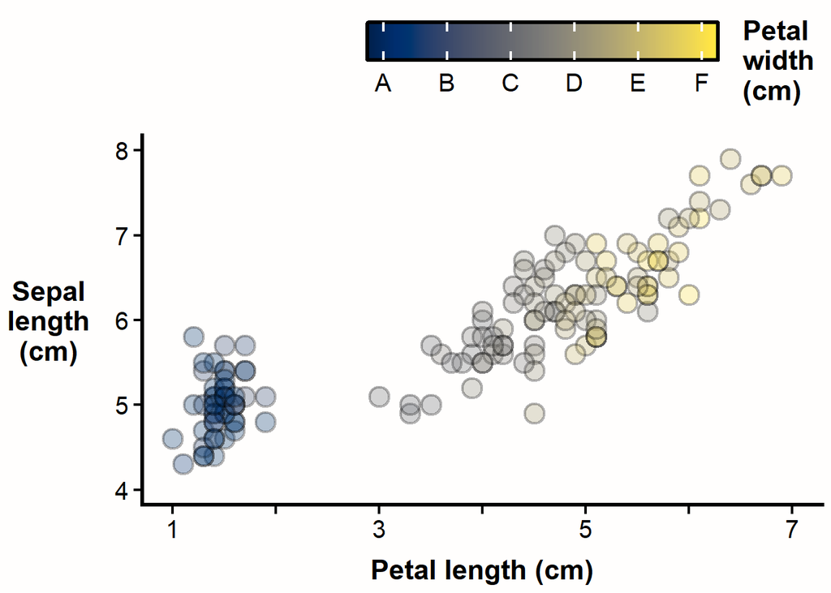

```r
ggplot(iris,
       mapping = aes(x = Petal.Length,
           y = Sepal.Length)) +
  geom_point(mapping = aes(fill = Petal.Width),
            alpha = 0.3) +
  theme_plus(axis.title.y = element_text( #<--CHANGE Y AXIS TITLE TO VERTICALLY JUSTIFIED AND HORIZONTAL.
               vjust = 0.5,
               angle = 0)) +
  scale_continuous_plus(scale = "x",
    name = "Petal length (cm)",
    thin.labels = TRUE) +
  scale_continuous_plus(scale = "y",
    name = "Sepal\nlength\n(cm)") + #<--INSERT LINE BREAKS USING \n TO BREAK TITLE ONTO MANY LINES FOR SPACE EFFICIENCY.
  scale_continuous_plus(scale = "fill",
    name = "Petal width (cm)",
    split_name = TRUE,
    labels = LETTERS[1:6]
    )
```

This works *reasonably* well. It’s readable, and it’s *relatively* simple to implement, if you know how (but that’s a **big** if for many `ggplot2` beginners!). But it has limitations:

- It steals horizontal space in the graph’s “center row” from your data, much as a right-hand legend would, forcing a similar amount of wasted void space above and below it.
- It keeps the label in a *relatively* unprominent location, where readers may not encounter it early.
- It doesn’t scale well to longer axis titles or those with long, unbreakable words. If one wants a descriptive, detail-rich title, it’s hard to achieve that with this approach.

To get around these challenges, `ggplotplus` includes `yaxis_title_plus()`, which “surgically” moves the y-axis title to above the y-axis line, left-justified to the plot margin:

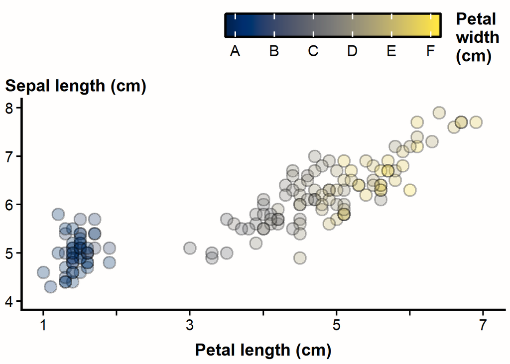

```r
ggplot(iris,
       mapping = aes(x = Petal.Length,
           y = Sepal.Length)) +
  geom_point(mapping = aes(fill = Petal.Width),
            alpha = 0.3) +
  theme_plus() + #<--NO THEME ADJUSTMENTS.
  scale_continuous_plus(scale = "x",
    name = "Petal length (cm)",
    thin.labels = TRUE) +
  scale_continuous_plus(scale = "y",
    name = "Sepal length (cm)") + #<--NO HACKS TO TITLE NEEDED.
  scale_continuous_plus(scale = "fill",
    name = "Petal width (cm)",
    split_name = TRUE,
    labels = LETTERS[1:6]
    ) +
  yaxis_title_plus() #<--THIS HANDLES EVERYTHING!
```

This may seem a *little* radical at first, but this small adjustment has many potential benefits that data visualization experts have been championing for decades:

- **Prominence**: Readers of left-to-right, top-to-bottom languages naturally start in the upper-left (this is called the **“Z reading frame,”** which is to say most humans read in a pattern that traces one or more Zs, starting at the top-left of an element), so the y-axis title is now one of the *first* elements many readers will encounter.
- **Readability**: The title is horizontal, making it easier and faster to read for all kinds of people in all kinds of contexts.
- **Space efficiency**: Instead of taking up room in the “data row” of the graph, the title sits in a narrow horizontal band *above* the plot, freeing up the core of the graphing area for your data to shine.
- **Pseudo-title element**: Many graph design advocates recommend against using plot titles. The reason is that, at best, titles tend to do what good y-axis titles and figure captions already do, only worse. However, research does suggest novice graph readers find titles helpful as “footholds.” By moving the y-axis title to where a plot (sub)title might go, it’s allowed to serve a similar purpose but with no risk of being repetitive with a plot title.
- **No ambiguity**: One hazard with moving the y-axis title to anywhere other than its “normal” location is that it may become unclear what it refers to. By anchoring it above the y-axis line and left-justifying it to the left edge of the y-axis labels, there’s little, if any, ambiguity as to its purpose. This is aided by `theme_plus()`’s default behavior to place any legend title at the top of the plot to the right rather than to the left of the legend keys.

Moving the y-axis title in this way is backed by **decades of advocacy** from the data visualization community. So while it’s optional, it’s not a fringe or new idea! Give it a try–you just might find you like it better too!

As noted above, if you’re using `yaxis_title_plus()` and `theme_plus()` together and your graph has a legend, the latter will default to a horizontal stripe at the top of the graph. By default, this stripe will sit in its own “row” above the relocated y-axis title.

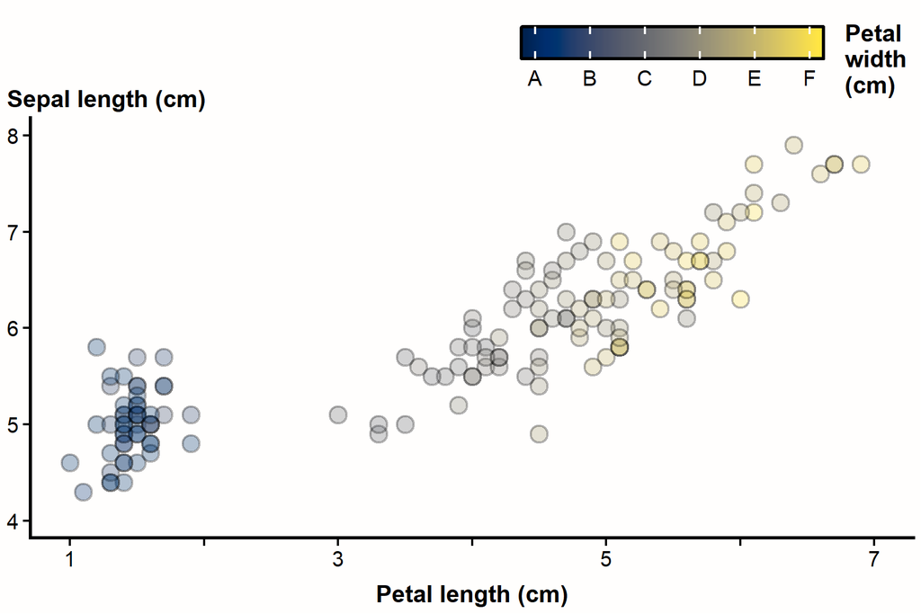

```r
#SAME GRAPH AS BEFORE, BUT NOW RENDERED AT A WIDTH/HEIGHT OF 9/6.
ggplot(iris,
       mapping = aes(x = Petal.Length,
           y = Sepal.Length)) +
  geom_point(mapping = aes(fill = Petal.Width),
            alpha = 0.3) +
  theme_plus() +
  scale_continuous_plus(scale = "x",
    name = "Petal length (cm)",
    thin.labels = TRUE) +
  scale_continuous_plus(scale = "y",
    name = "Sepal length (cm)") +
  scale_continuous_plus(scale = "fill",
    name = "Petal width (cm)",
    split_name = TRUE,
    labels = LETTERS[1:6]
    ) +
  yaxis_title_plus(nudgeTopLegendDown = TRUE) #<--MOVE TOP LEGEND(S) DOWN INTO SAME ROW AS Y AXIS TITLE.
```

## 8 (EXPERIMENTAL) Direct Labeling as an Alternative to a Legend

When mapping categorical data to a non-positional visual channel (such as the x or y-axes), the most common approach is to use a **legend** to clarify which categories in the data correspond to which styles, orientations, symbols, colors, etc. are shown. As we’ve seen, legends can be designed to be efficiently placed along a reader’s likely Z reading frame by placing them horizontally above or below the plot.

However, this can still be relatively space-inefficient and demanding on the reader relative to another option often recommended by data visualization experts: **direct labeling.** This is where labels are placed within the plotting area to mark groups in lieu of a legend. This concentrates information, prevents readers from having to jump their gaze back and forth between the plotting area and the legend, and reduces the risk a reader may fail to notice a legend when forming initial conclusions, among other potential benefits.

In practice, direct labeling in `ggplot2` is a little cumbersome. Generally, one would use `ggplot2`’s `annotate()` or `geom_text()` functions to manually choose a location for each label, guessing and checking to ensure adequate sizing and placement and to avoid overlapping labels with each other or with underlying points.

To demonstrate, let’s bin petal widths so I have a second categorical variable other than `Species` to work with:

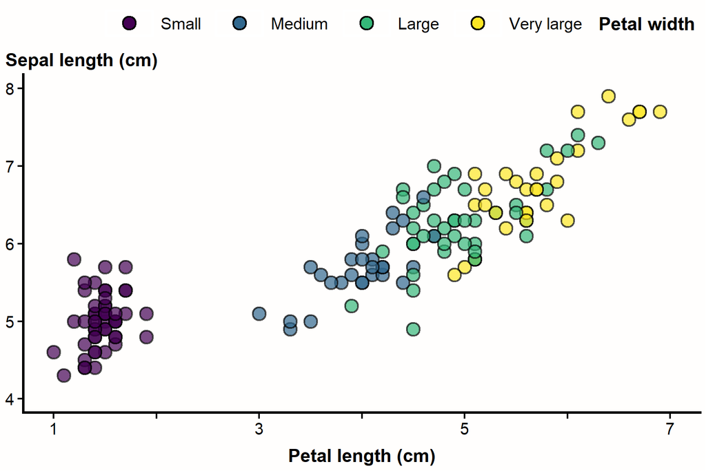

```r
iris$Petal.Width.Binned = ggplot2::cut_interval(
  iris$Petal.Width,
  n = 4,
  labels = c("Small", "Medium", "Large", "Very large")
) #<--CUT INTO 4 GROUPS BY PETAL.WIDTH VALUE

ggplot(iris,
       mapping = aes(x = Petal.Length,
                     y = Sepal.Length)) +
  geom_point(mapping = aes(fill = Petal.Width.Binned), #<--MOVE TO A DISCRETE FILL MAPPING.
             alpha = 0.7) + #<--LESS TRANSPARENT FOR BETTER GROUP CLARITY.
  theme_plus(begin_discrete = 0, #<--RETURN TO FULL DISCRETE SCALE.
             end_discrete = 1) +
  scale_continuous_plus(scale = "x",
                        name = "Petal length (cm)",
                        thin.labels = TRUE) +
  scale_continuous_plus(scale = "y",
                        name = "Sepal length (cm)") +
  labs(fill = "Petal width") +
  yaxis_title_plus() #<--DON'T NUDGE
```

Here’s how one might manually direct-label groups in this plot:

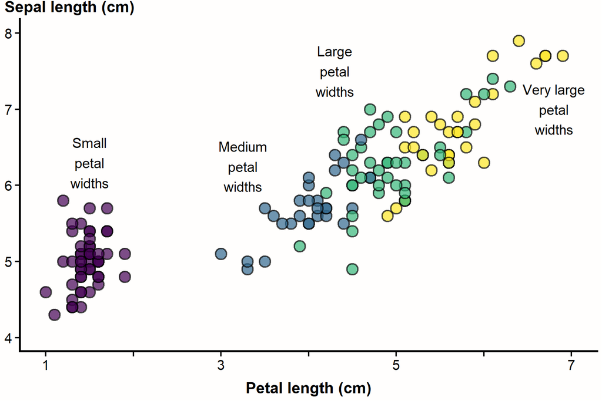

```r
ggplot(iris,
       mapping = aes(x = Petal.Length,
                     y = Sepal.Length)) +
  geom_point(mapping = aes(fill = Petal.Width.Binned),
             alpha = 0.7) +
  theme_plus(begin_discrete = 0,
             end_discrete = 1) +
  scale_continuous_plus(scale = "x",
                        name = "Petal length (cm)",
                        thin.labels = TRUE) +
  scale_continuous_plus(scale = "y",
                        name = "Sepal length (cm)") +
  yaxis_title_plus() +
  annotate(geom = "text", x = 1.5, y = 6.3, label = "Small\npetal\nwidths") + #<-MANUAL ANNOTATIONS, ONE PER GROUP, WITH AN X AND Y MANUALLY SELECTED THRU TRIAL AND ERROR.
  annotate(geom = "text", x = 3.25, y = 6.25, label = "Medium\npetal\nwidths") +
  annotate(geom = "text", x = 4.3, y = 7.5, label = "Large\npetal\nwidths") +
  annotate(geom = "text", x = 6.8, y = 7, label = "Very large\npetal\nwidths") +
  guides(fill = "none") #<-NO LONGER A NEED FOR A LEGEND.
```

This works, but it’s a bit tedious and requires manual trial and error to get the positioning right. Plus, in this case, there’s some ambiguity about which groups go with which labels for the two right-most groups.

`direct_labels_plus()` leverages the `geom_label_repel()` function from the `ggrepel` package. The latter allows you to place labels on points, lines, or other data elements that will then repel one another using an algorithm so they don’t bunch up. `direct_labels_plus()` extends that functionality to include repelling labels away from not only each other but the data elements they might be labeling too so the labels will not (generally) cover up the data. Here’s how to use it:

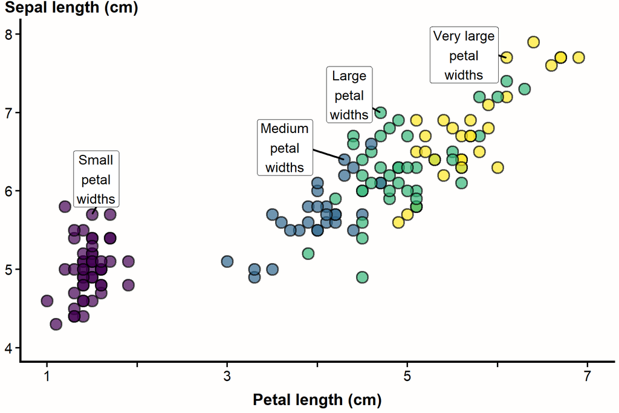

```r
ggplot(iris,
       mapping = aes(x = Petal.Length,
                     y = Sepal.Length)) +
  geom_point(mapping = aes(fill = Petal.Width.Binned),
             alpha = 0.7) +
  theme_plus(begin_discrete = 0,
             end_discrete = 1) +
  scale_continuous_plus(scale = "x",
                        name = "Petal length (cm)",
                        thin.labels = TRUE) +
  scale_continuous_plus(scale = "y",
                        name = "Sepal length (cm)") +
  yaxis_title_plus() +
  guides(fill = "none") +
  direct_labels_plus(data = iris, #<--PROVIDE THE DATA AGAIN.
                     x = Petal.Length, #<-SPECIFY THE X AND Y VARIABLES AGAIN.
                     y = Sepal.Length,
                     group = Petal.Width.Binned, #<--SPECIFY VARIABLE TO LABEL BY.
                     placement = "top", #<-SHOULD LABELS BE TOWARDS THE TOP, RIGHT, BOTTOM, OR LEFT EDGE OF A GROUP'S POINTS/LINES?
                     geometry = "point", #POINTS OR LINES TO LABEL?
                     key_labels = c("Small" = "Small\npetal\nwidths", #PROVIDE key_labels A NAMED VECTOR TO REPLACE THE CONTENTS OF LABELS USING "OLD NAME" = "NEW NAME" FORMAT.
                       "Medium" = "Medium\npetal\nwidths",
                       "Large" = "Large\npetal\nwidths",
                       "Very large" = "Very large\npetal\nwidths")
                     )
```

Here, at least, this configuration works well–there’s no ambiguity about which fill colors go with which labels, there’s no longer a need for a legend, and there was ample void space within the plotting area to facilitate this approach.

While I wouldn’t necessarily recommend using direct labeling in the context of faceting (“small multiples”), `direct_labels_plus()` will work with faceting so long as you supply either or both faceting variables to `facet_vars`:

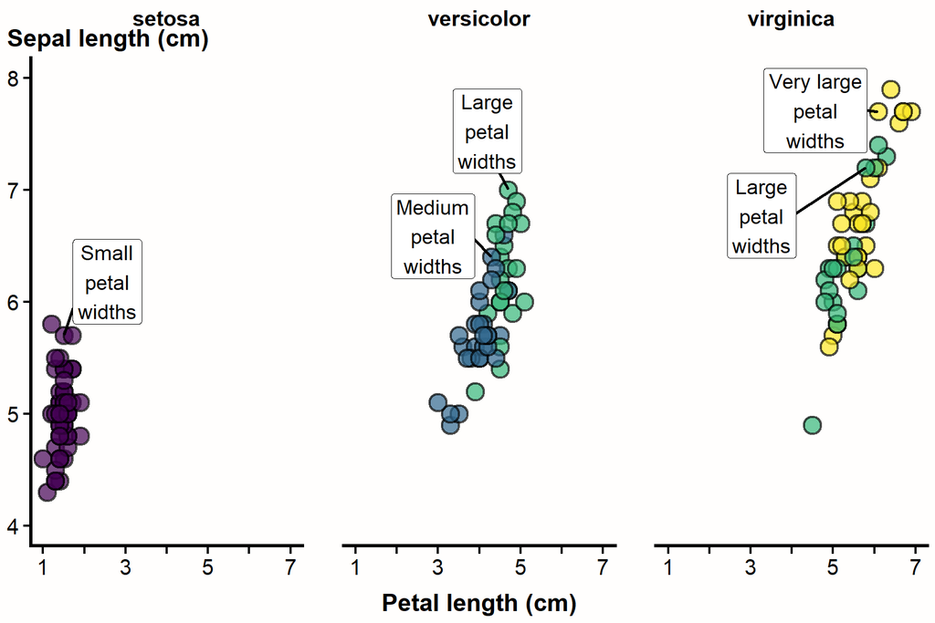

```r
ggplot(iris,
       mapping = aes(x = Petal.Length,
                     y = Sepal.Length)) +
  geom_point(mapping = aes(fill = Petal.Width.Binned),
             alpha = 0.7) +
  theme_plus(begin_discrete = 0,
             end_discrete = 1) +
  scale_continuous_plus(scale = "x",
                        name = "Petal length (cm)",
                        thin.labels = TRUE) +
  scale_continuous_plus(scale = "y",
                        name = "Sepal length (cm)") +
  yaxis_title_plus() +
  guides(fill = "none") +
  direct_labels_plus(data = iris,
                     x = Petal.Length,
                     y = Sepal.Length,
                     group = Petal.Width.Binned,
                     facet_vars = "Species", #<--SUPPLY A 1- OR 2-LENGTH CHARACTER VECTOR OF THE VARIABLES YOU'LL USE IN FACETING.
                     placement = "top",
                     geometry = "point",
                     size = 5,
                     box.padding = 0.5,
                     max.overlaps = Inf,
                     segment.size = 1,
                     min.segment.length = 0,
                     key_labels = c("Small" = "Small\npetal\nwidths",
                                    "Medium" = "Medium\npetal\nwidths",
                                    "Large" = "Large\npetal\nwidths",
                                    "Very large" = "Very large\npetal\nwidths")
  ) +
  facet_grid(. ~ Species) #<--FACET INTO COLUMNS BY SPECIES
```

`direct_labels_plus()` will also work with line-type graphs:

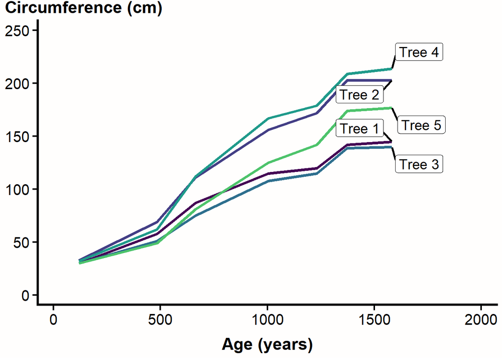

```r
##COMPLETELY DIFFERENT DATA TO SHOW DIRECT LABELLING ON A LINE GRAPH
ggplot(Orange, aes(
  x = age,
  y = circumference,
  color = factor(Tree, levels = unique(sort(as.numeric(Tree)))) #<--TO MAKE CATEGORICAL DATA.
)) +
  geom_line() +
  theme_plus() +
  yaxis_title_plus() +
  scale_continuous_plus(scale = "x", name = "Age (years)") +
  scale_continuous_plus(scale = "y", name = "Circumference (cm)") +
  labs(color = "Tree") +
  scale_color_discrete(guide = "none") +
  direct_labels_plus(
    data = Orange,
    x = age,
    y = circumference,
    group = Tree,
    placement = "right",
    geometry = "line",
    size = 5,
    box.padding = 0.5,
    max.overlaps = Inf,
    segment.size = 1,
    min.segment.length = 0,
    key_labels = paste("Tree", 1:5) #<--IF PROVIDING AN UNNAMED VECTOR, THE GROUPS WILL BE RELABELED IN ALPHANUMERIC ORDER.
  )
```